# Statistical Methods

Assumptions and Diagnostics II

Fall 2025 | Course PSYC 790  
Jeffrey M. Girard | Lecture 12b

# Overview

## Assumptions Overview

- **Assumptions about the Formula**
  - Correct Functional Form
  - Perfectly Measured Predictors
  - No Collinearity/Multicollinearity
- **Assumptions about the Residuals**
  - Constant Error Variance
  - Normality of Residuals
  - Independence of Residuals

# Constant Error Variance

## Assumption

- For any value of $x$, the residual variance are constant
  - The spread of points around the line must be consistent
  - This is similar to Student’s assumption of equal group variances
- This is also called “homoscedasticity” or “homogeneity of variance”
  - When violated, we say that there is “heteroscedasticity”

**Consequences of Violating**

Bias in standard errors only

## Assumption Examples

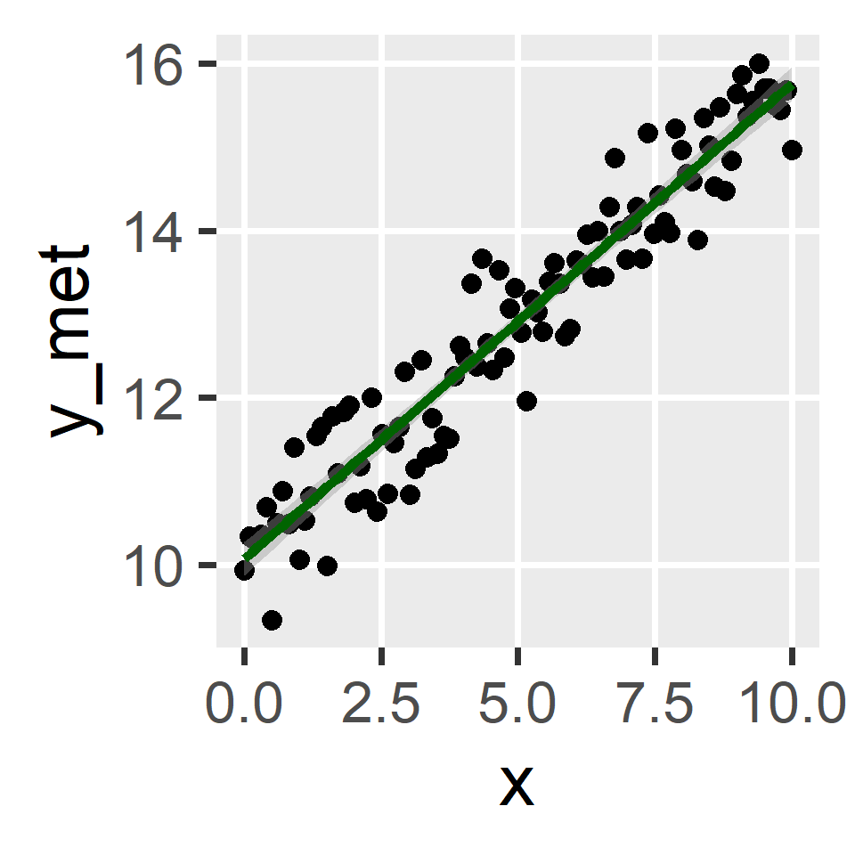

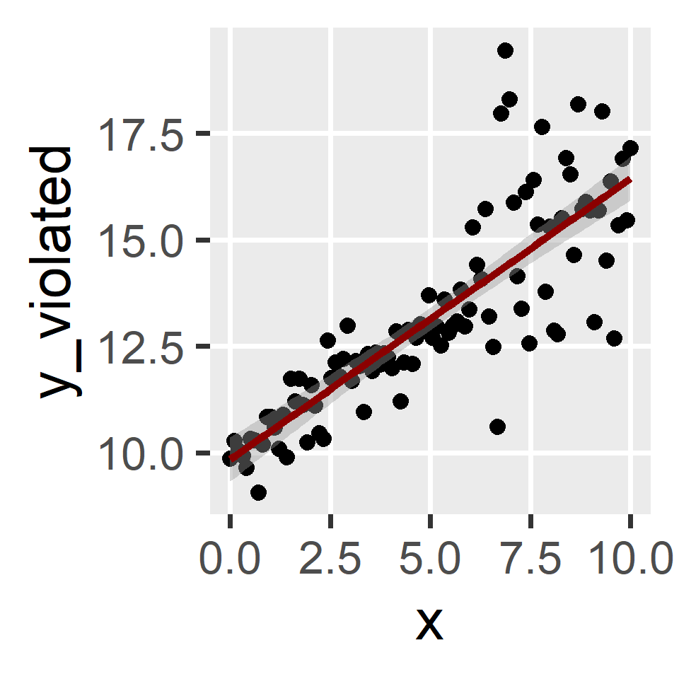

## Diagnostics

1. Breusch-Pagan heteroscedasticity test
   - A significant result indicates heteroscedasticity
   - But this test gets more power with a larger sample…

`check_heteroscedasticity(fit)`

2. Plot the residuals against the fitted values
   - (Or some derivative of the residuals)

`check_model(fit, check = "homogeneity")`

## Example: Assumption Met

```r
library(easystats)
check_heteroscedasticity(fit_met)
## OK: Error variance appears to be homoscedastic (p = 0.192).
```

```r
check_model(fit_met, check = "homogeneity")
```

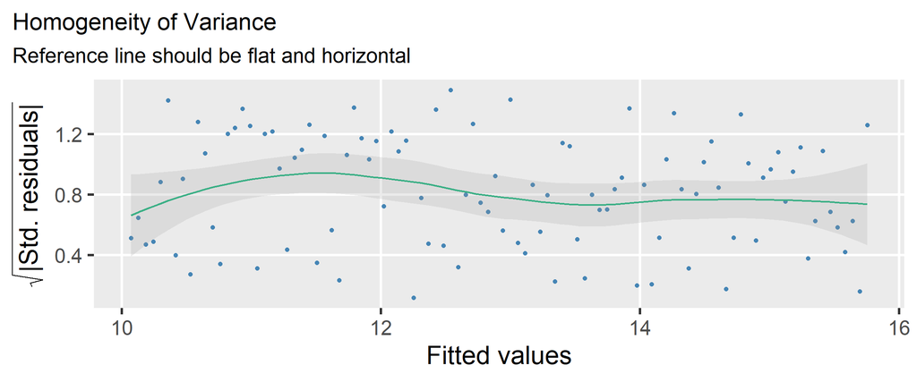

```r
see:::plot.see_check_model(check_model(fit_met, check = "homogeneity", panel = FALSE))$HOMOGENEITY +
  mytheme(24) +
  theme(
    plot.title.position = "plot",
    plot.title = element_text(hjust = 0, size = 22),
    plot.subtitle = element_text(hjust = 0, size = 20)
  )
```

## Example: Assumption Violated

```r
check_heteroscedasticity(fit_violated)
## Warning: Heteroscedasticity (non-constant error variance) detected (p < .001).
```

```r
check_model(fit_violated, check = "homogeneity")
```

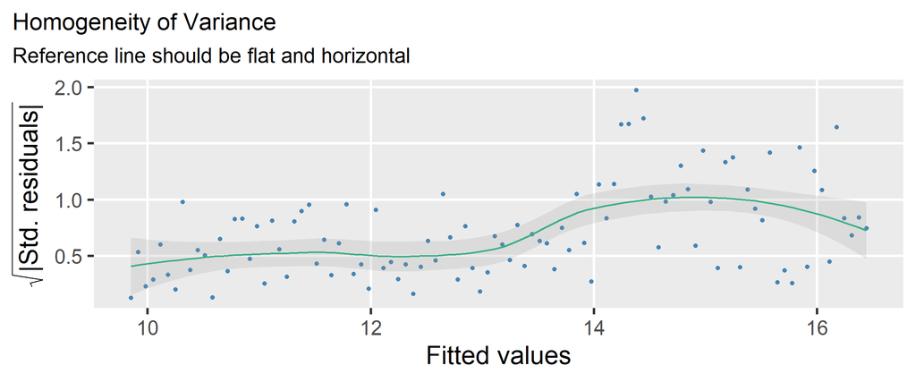

```r
see:::plot.see_check_model(check_model(fit_violated, check = "homogeneity", panel = FALSE))$HOMOGENEITY +
  mytheme(24) +
  theme(
    plot.title.position = "plot",
    plot.title = element_text(hjust = 0, size = 22),
    plot.subtitle = element_text(hjust = 0, size = 20)
  )
```

## Solutions

1. Transform the outcome variable
   - e.g., Log or power transformations
2. Adjust the standard errors
   - e.g., Huber-White (sandwich) estimation
3. Model the error variance explicitly
   - e.g., weighted least squares estimation
   - e.g., location-scale models

# Normal Residuals

## Assumption

- The residuals are normally distributed around the line
  - The spread around the line is a bell curve
  - This is more problematic with smaller samples
  - Non-normal residuals may signal other problems

**Consequences of Violating**

Standard errors will be biased

## Examples

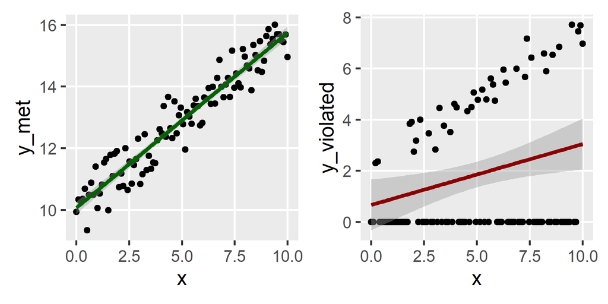

## Diagnostics

1. Plot the residuals’ distribution
   - Visually compare density plot to normal distribution
   - Assumption is violated to the extent they differ
2. Use a quantile-quantile (QQ) plot
   - Visually compare the sample and normal quantiles
   - Assumption is violated if dots stray from the line
3. Use the Shapiro-Wilk test
   - A significant result indicates non-normality
   - But this test gets more power with a larger sample…

## Example: Residual Distribution

```r
fit_met <- lm(y_met ~ x, data = d4)
fit_violated <- lm(y_violated ~ x, data = d4)
```

```r
check_model(fit_met,
            check = "normality")
```

```r
check_model(fit_violated,
            check = "normality")
```

```r
p1 <- see:::plot.see_check_model(check_model(fit_met, check = "normality", panel = FALSE))$NORM +
  mytheme(14)

p2 <- see:::plot.see_check_model(check_model(fit_violated, check = "normality", panel = FALSE))$NORM +
  mytheme(14)

(p1 | p2)
```

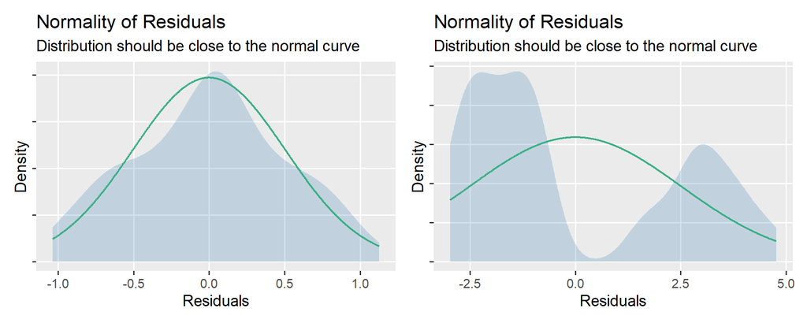

## Example: QQ Plot

```r
check_model(fit_met,
            check = "qq")
```

```r
check_model(fit_violated,
            check = "qq")
```

```r
p1 <- see:::plot.see_check_model(check_model(fit_met, check = "qq", panel = FALSE))$QQ +
  mytheme(14)

p2 <- see:::plot.see_check_model(check_model(fit_violated, check = "qq", panel = FALSE))$QQ +
  mytheme(14)

(p1 | p2)
```

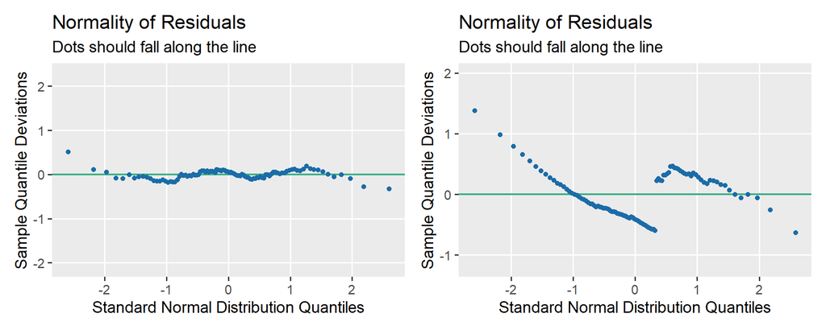

## Example: Shapiro-Wilk Test

```r
check_normality(fit_met)
## OK: residuals appear as normally distributed (p = 0.320).

check_normality(fit_violated)
## Warning: Non-normality of residuals detected (p < .001).
```

## Solutions

1. Transform your outcome to be more normal
   - e.g., Box-Cox transformations
   - e.g., Yeo-Johnson transformations
2. Use a nonparametric approach
   - e.g., nonparametric bootstrapping
   - e.g., rank-based nonparametrics
3. Model the outcome as non-normal
   - e.g., generalized linear modeling (GLM)

Note that addressing other issues may also help here.

# Independent Residuals

## Assumption

- The residuals must be independent of (not related to) one another
  - This will be met in any random sample from a population
  - It will be *violated* with **clustered** or **autocorrelated** data
  - Clustered data has many observations from the same “group”
  - Autocorrelated data has many observations close in time

**Consequences of Violating**

Standard errors will be downwardly biased (i.e., deflated)

## Example: Clustering

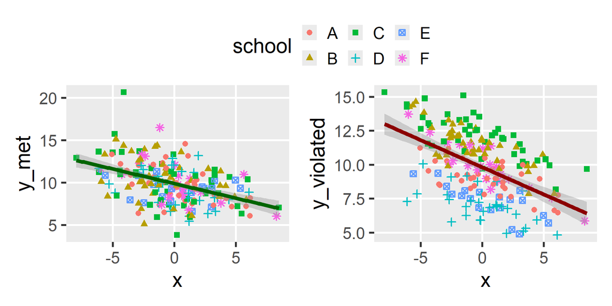

## Example: Autocorrelation

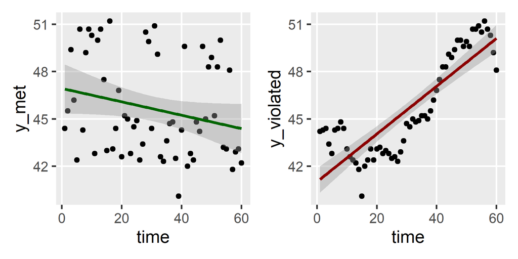

## Diagnostics

1. If there is a potential clustering variable, do residuals differ?
   - Examine distribution of residuals in each cluster
   - Calculate a multilevel intraclass correlation
2. Is there autocorrelation between residuals?
   - Use the Durbin-Watson serial dependency test
   - Significance indicates autocorrelation

`check_autocorrelation(fit)`

## Example: No Clustering

```r
qplot(x = school, y = residuals(fit_met1), data = d2a, geom = "boxplot")
```

```r
qplot(x = school, y = residuals(fit_met1), data = d2a, geom = "boxplot") +
  mytheme(24)
```

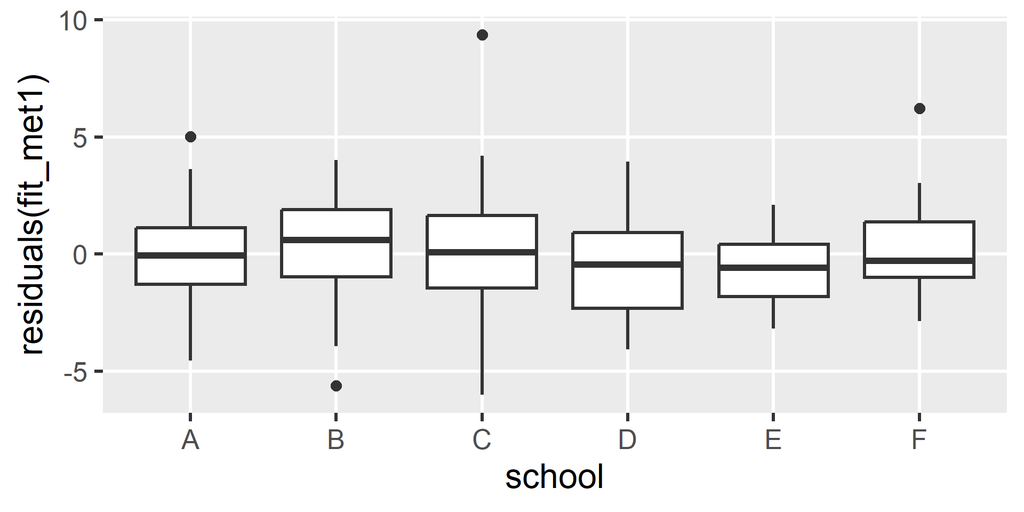

## Example: Clustering

```r
qplot(x = school, y = residuals(fit_violated1), data = d2a, geom = "boxplot")
```

```r
qplot(x = school, y = residuals(fit_violated1), data = d2a, geom = "boxplot") +
  mytheme(24)
```

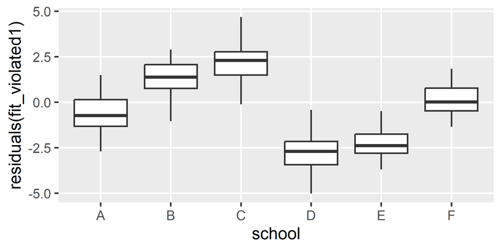

## Example: Autocorrelation

```r
check_autocorrelation(fit_met2)
## OK: Residuals appear to be independent and not autocorrelated (p = 0.416).

check_autocorrelation(fit_violated2)
## Warning: Autocorrelated residuals detected (p < .001).
```

## Solutions

1. Adjust the standard errors
   - e.g., cluster-robust standard errors
2. Model the clustering explicitly
   - e.g., fixed-effects modeling
   - e.g., multilevel modeling (MLM, HLM, LME, LMM)
   - e.g., generalized estimating equations (GEE)
3. Model the serial dependency
   - e.g., time series analysis (ARIMA)
   - e.g., autoregressive models (DSEM)

# Outliers

## Definition

- Outliers are **atypical observations** that do not fit the other data
  - They may represent data contaminated by errors
  - Or they may represent real but rare cases
- Outliers can have **large impacts** on the results of your model
  - Results may reflect the outliers rather than general patterns
- So we need to be watchful for outliers and deal with them carefully
  - We should also be transparent about reporting our approach

## Examples

```r
yearspubs <- read_csv("../data/yearspubs.csv", show_col_types = FALSE)
```

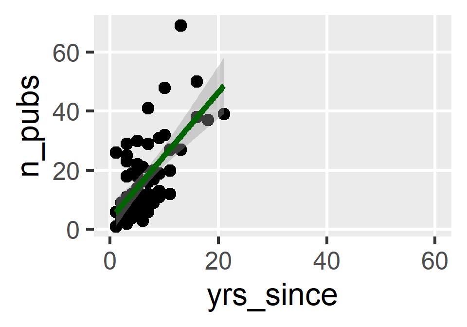

```r
qplot(yrs_since, n_pubs, data = yearspubs, geom = "point") +
  geom_smooth(method = "lm", color = "darkgreen") +
  coord_cartesian(xlim = c(0, 60)) +
  mytheme(24)
```

$$b_0=3.4, b_1=2.2^\ast$$

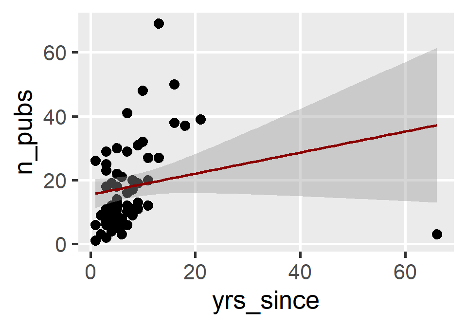

```r
dat_with <- yearspubs
dat_with[2, 1] <- 66
qplot(yrs_since, n_pubs, data = dat_with, geom = "point") +
  geom_smooth(method = "lm", linewidth = 1, color = "darkred") +
  mytheme(20)
```

$$b_0=15.5^\ast, b_1= 0.3$$

## Diagnostics

For each observation, we can calculate its…

1. **Leverage:** How unusual are its $x$ values?
   - e.g., $h_{ii}$ and Mahalonabis distance
2. **Distance:** How far is it from the regression line?
   - e.g., raw, standardized, or Studentized residuals
3. **Influence:** How much does it change the coefficients?
   - e.g., $\text{DFFITS}_i$, $\text{DFBETAS}_i$, and Cook’s $D_i$

## Example: No Outliers

```r
check_outliers(fit_without, method = c("cook", "mahalanobis"))
## OK: No outliers detected.
## - Based on the following methods and thresholds: cook (0.701), mahalanobis (13.816).
## - For variable: (Whole model)
```

## Example: With Outliers

```r
check_outliers(fit_with, method = c("cook", "mahalanobis"))
## 1 outlier detected: case 2.
## - Based on the following methods and thresholds: cook (0.701),
##   mahalanobis (13.816).
## - For variable: (Whole model).
##
## Note: Outliers were classified as such by at least half of the selected methods.
##
## -----------------------------------------------------------------------------
##
## The following observations were considered outliers for two or more
##   variables by at least one of the selected methods:
##
##   Row  n_Mahalanobis         n_Cook
## 1   2 (Multivariate) (Multivariate)
```

## Solutions

1. **Fix** the outliers
   - If they are errors/contaminations, fix them
2. **Keep** the outliers
   - If they belong to your distribution, maybe keep them
3. **Remove** the outliers
   - If they belong to a different distribution, maybe remove them
4. **Recode** the outliers
   - If you want to reduce their influence, maybe Winsorize them

## Remove the Outliers

If you do choose to remove the outliers, here’s how

```r
# Number of observations before removing outliers
nrow(dat_with)
## [1] 62

# Identify outliers
outliers <- check_outliers(fit_with, method = c("cook", "mahalanobis"))

# Remove outliers
dat_drop <- dat_with[!as.numeric(outliers), ]

# Number of observations after removing outliers
nrow(dat_drop)
## [1] 61
```